# Report

#### Group menber: Mo,Yun; Hu,Chen; Yan,Nan; Yu,Qiaochu

Github: https://github.com/stat605-final-project/Noaa_data_analysis

### 1. Introduction

The data we used in our project is NOAA Global Historical Climatology Network(GHCN) Daily, which is an integrated database of daily climate summaries from land surface stations across the globe. (https://www.kaggle.com/noaa/noaa-global-historical-climatology-network-daily)

As for statistical computation, we use CHTC to download and restructure the dataset. And then we use R to analyze the structured data.

### 2. Body

### 2.1 Data Description

GHCN-Daily contains records from over 100,000 stations in 180 countries and territories, providing numerous daily variables, including maximum and minimum temperature, total daily precipitation, snowfall, and snow depth. We choose observations of TMAX(maximum temperature), TMIN(minimum temperature) and PRCP (total daily precipitation) from Station USW00094728 (NY CITY CENTRAL PARK, NY US) of year 1877 to 2018. The period of record of this station covers all year we chose.

The original datasets in csv form are compressed in corresponding .gz files, which are further compressed into an extremely large .gz file. The size of the original .gz file is around 14 GB and the size of original csv files vary from 100MB to 1.5GB.

### 2.2 Data Download in CHTC

We process each year as one job in CHTC. Since it costs too much time and memory to download the whole data(14 GB) and uncompress all of them in CHTC, to resolve this, we download original csv file on local computer, and upload them to google drive. In CHTC, we download them via share link of each csv files. Though the idea is simple, in practice it is not an easy job to download from google drive in a parallel way in CHTC. We try and modify multiple commands to solve problems like the file is too big to be read completely. (Corresponding code is getdata.sh/getdata.sub.)

### 2.3 Data Clean in CHTC

To clean data, we choose the target station and extract target variables in CHTC (Corresponding code is megre.sh). Finally, we have 3 csv files (TMIN,TMAX and PRCP) with structured data. The size of each is around 1 M. The continuing statistics analysis based on structured data are implemented in R.

### 2.4 Analysis of merged data

(Code1.R, Code2.R)

#### (1) First, we calculated the Max/Min/Mean for the three variables. Draw the time series plot and the acf plot as following:

#### PRCP

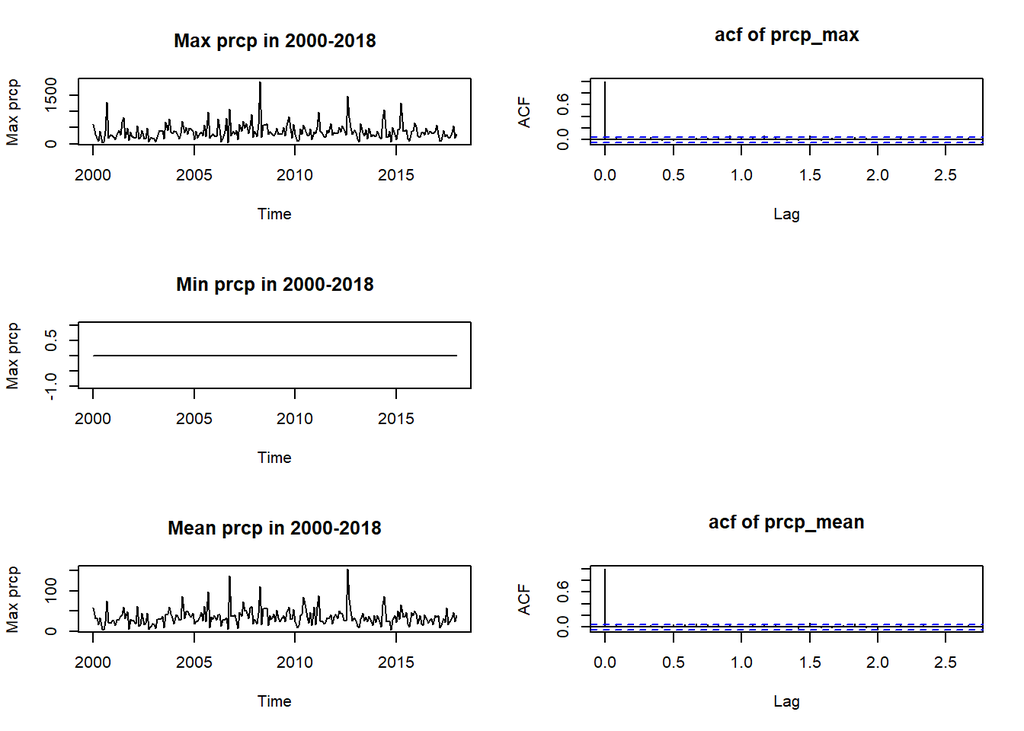

#### TMAX

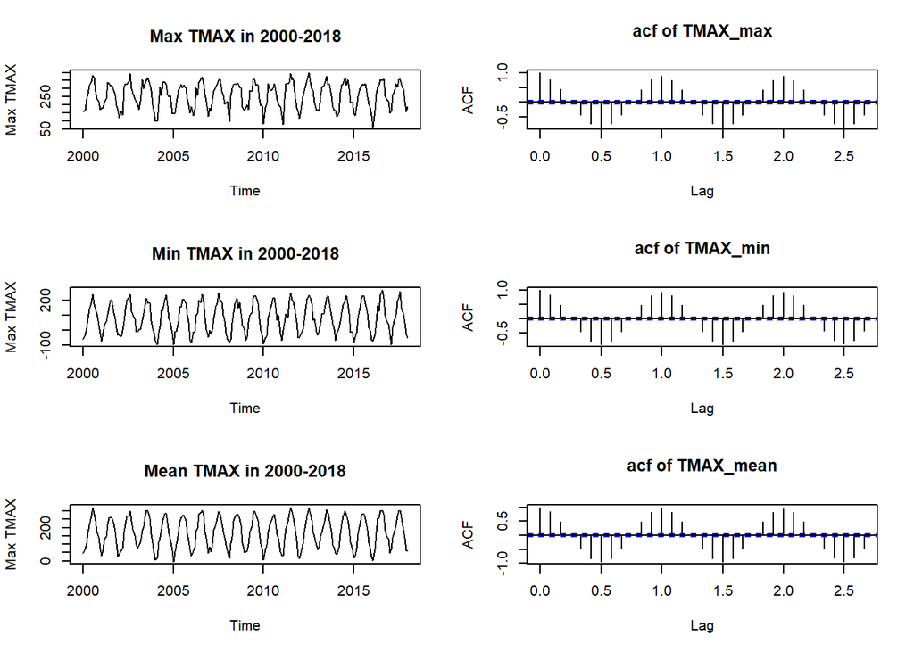

#### TMIN

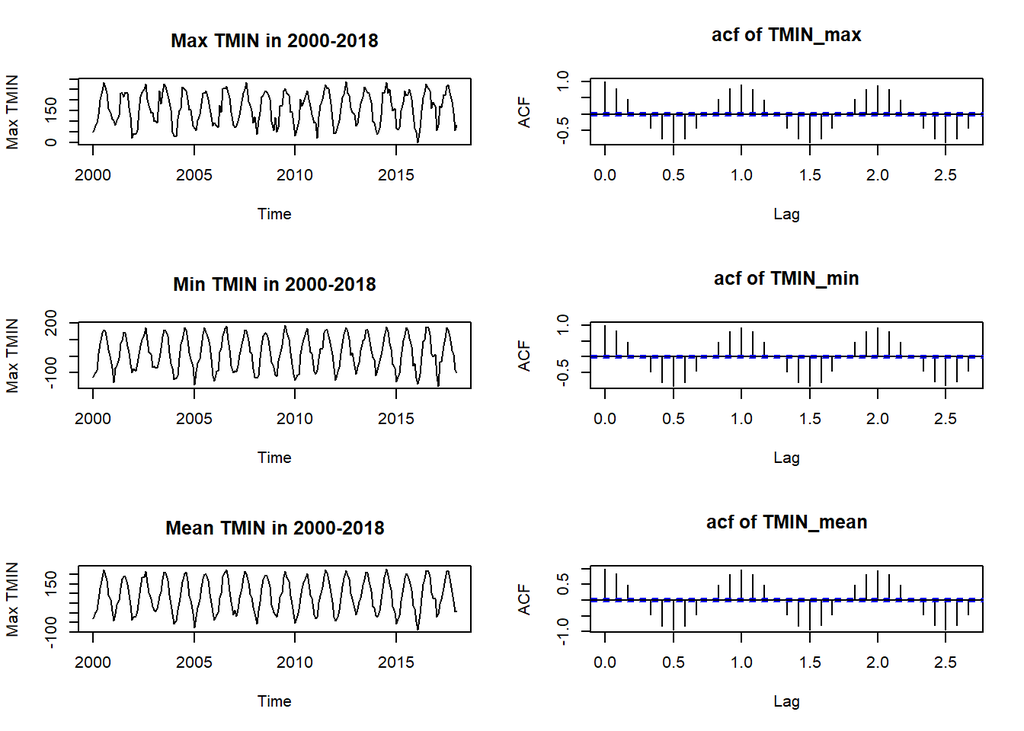

**From the plot, we observe that:**

1. Max of prcp and mean of prcp shows no pattern.
2. Max/Min/Mean of TMAX and TMIN show a strong seasonal time series patten.

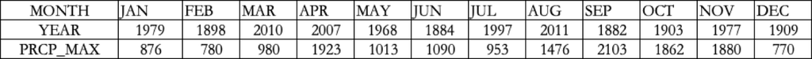

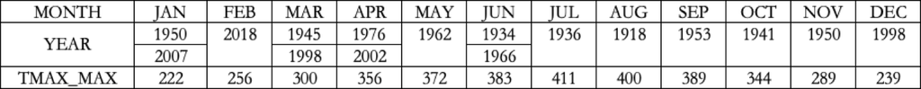

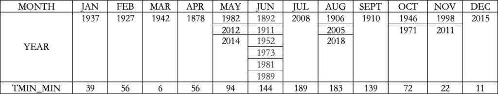

From table, we can see the years of extreme value show no patten of cluster or other trend. So it may be hard to forcast the extreme values.

### 2.5 Weakness

When we process each year using CHTC, it is very strange that some years will generate three empty files(tmax/tmin/prcp). We run it several times, but the missing years are totally random, also the corresponding .err files are empty and provide no information. So we have to additionally fill in value for these years by ourselves.

### 3. Conclusion

From the time series plot and acf plot, we found that max/mean for PRCP shows no trend and can be seen as random. Besides, the max/min/mean for TMAX and TMIN show a strong seasonal trend. So in future work we can utilize this trend to build a time series model in order to forcast the TMAX and TMIN.